# A3

Author

Sheeba Moghal

# Introduction

At Chiba University Hospital, data was gathered over a number of years to create a database. A few of the patients who came to the hospital’s outpatient clinic had conditions related to collagen. An adjacent private clinic’s family doctor recommended the hospital to them. Thrombosis is a significant and severe consequence of collagen illnesses and a leading cause of death. Thrombosis is a condition where blood clots more easily and obstructs blood arteries. Treatment for thrombosis needs to be emergency-oriented, and early detection and risk assessment are crucial.

# Data Exploration

# Data Pre-processng

Before the visual exploration, we will first attempt to understand and clean the data.

```python
# Importing the libraries
import numpy as np
import pandas as pd
import seaborn as sns
import matplotlib.pyplot as plt
from statsmodels.graphics.mosaicplot import mosaic
from scipy.stats import chi2_contingency
plt.style.use('/Users/sheebamoghal/.matplotlib/stylelib/sheeba_style.mplstyle')

# Reading the files

ana=pd.read_csv('data/ana-pattern.csv')
diagnosis=pd.read_csv('data/diagnosis.csv')
exam=pd.read_csv('data/exam.csv')
patient=pd.read_csv('data/patient-info.csv')
symptoms=pd.read_csv('data/symptoms.csv')
```

## Data Set Exploration

### 1. ANA

```python
print(ana.head(5))
print(ana.dtypes)
# the examination is not in pd.date format
ana['examination_date']= pd.to_datetime(ana['examination_date'])
```

```
         id examination_date ana_pattern
0   14872.0       1997-05-27           P
1   48473.0       1992-12-21           P
2   48473.0       1992-12-21           S
3  108788.0       1997-05-06           S
4  122405.0       1998-04-02           P
id                  float64
examination_date     object
ana_pattern          object
dtype: object
```

```python
print(ana.dtypes)
ana_dup=ana.duplicated(subset=['id'])
print(ana_dup)
# shape before any processing
beforeana= ana.shape
print(beforeana)
# dropping all the duplicate ids.
ana=ana.dropna(subset='id')
# after dropping, the following is the shape
print(ana.shape)
# checking missing values
print(ana.isnull().sum())
```

```
id                         float64
examination_date    datetime64[ns]
ana_pattern                 object
dtype: object
0      False
1      False
2       True
3      False
4      False
       ...
653     True
654     True
655     True
656     True
657     True
Length: 658, dtype: bool
(658, 3)
(644, 3)
id                  0
examination_date    3
ana_pattern         0
dtype: int64
```

### 2. Diagnosis

```python
print(diagnosis.head(10))
print(diagnosis.dtypes)
print(diagnosis['diagnosis'].unique())
diagnosis['examination_date']=pd.to_datetime(diagnosis['examination_date'])
print(diagnosis.dtypes)
# shape before the data preprocessing
beforediagnosis= diagnosis.shape
print(beforediagnosis)
diagnosis=diagnosis.dropna(subset='id')
# shape after preprocessing
print(diagnosis.shape)
print(diagnosis.isnull().sum())
```

```
         id examination_date                        diagnosis
0   14872.0       1997-05-27  MIXED CONNECTIVE TISSUE DISEASE
1   14872.0       1997-05-27                            OTHER
2   48473.0       1992-12-21     SYSTEMIC LUPUS ERYTHEMATOSUS
3  102490.0       1995-04-20          PAGET-SCHOTTER SYNDROME
4  122405.0       1998-04-02     SYSTEMIC LUPUS ERYTHEMATOSUS
5  122405.0       1998-04-02         STEVENS-JOHNSON SYNDROME
6  122405.0       1998-04-02                            OTHER
7  133382.0       1996-10-17     SYSTEMIC LUPUS ERYTHEMATOSUS
8  174116.0       1995-11-13     SYSTEMIC LUPUS ERYTHEMATOSUS
9  174116.0       1995-11-13                            OTHER
id                  float64
examination_date     object
diagnosis            object
dtype: object
['MIXED CONNECTIVE TISSUE DISEASE' 'OTHER' 'SYSTEMIC LUPUS ERYTHEMATOSUS'
 'PAGET-SCHOTTER SYNDROME' 'STEVENS-JOHNSON SYNDROME' "RAYNAUD'S SYNDROME"
 'RHEUMATOID ARTHRITIS' 'IMMUNE THROMBOCYTOPENIA' "BEHCET'S DISEASE"
 'INTERFERON GAMMA INDUCIBLE PROTEIN-10' 'FEVER'
 'ANTIPHOSPHOLIPID SYNDROME' 'DIABETES MELLITIS' 'ABORTION' 'PREGNANCY'
 'PARTICULATE MATTER' 'PAROXYSMAL NOCTURNAL HEMOGLOBINURIA'
 'COLLAGEN DISEASE' 'AORTITIS' 'ADULT STILL DISEASE'
 'JUVENILE RHEUMATOID ARTHRITIS' 'POLYMYALGIA RHEUMATICA' 'ADIE SYNDROME']
id                         float64
examination_date    datetime64[ns]
diagnosis                   object
dtype: object
(2140, 3)
(2122, 3)
id                     0
examination_date    1515
diagnosis              0
dtype: int64
```

### 3. Exam

The exam data deals with a huge amount of missing values, and hence, irrespective of the shape, the missing values will still be retained to focus on the question.

```python
print(exam.head(5))
print(exam.dtypes)
exam['examination_date']=pd.to_datetime(exam['examination_date'])
exambefore=exam.shape
print(exambefore)
exam=exam.dropna(subset='id')
print(exam.shape)
print(exam.isnull().sum())
```

```
         id examination_date  a_cl_ig_g  a_cl_ig_m  ana  a_cl_ig_a  kct rvvt  \
0   14872.0       1997-05-27        1.3        1.6  256        0.0  NaN  NaN
1   48473.0       1992-12-21        4.3        4.6  256        3.3    -    -
2  102490.0       1995-04-20        2.3        2.5    0        3.5  NaN  NaN
3  108788.0       1997-05-06        0.0        0.0   16        0.0  NaN  NaN
4  122405.0       1998-04-02        0.0        4.0    4        0.0  NaN  NaN

   lac  thrombosis     severity
0    -        True  most severe
1    -       False          NaN
2  NaN       False          NaN
3    -       False          NaN
4  NaN       False          NaN
id                  float64
examination_date     object
a_cl_ig_g           float64
a_cl_ig_m           float64
ana                  object
a_cl_ig_a           float64
kct                  object
rvvt                 object
lac                  object
thrombosis             bool
severity             object
dtype: object
(806, 11)
(770, 11)
id                    0
examination_date      7
a_cl_ig_g             0
a_cl_ig_m             0
ana                  20
a_cl_ig_a             0
kct                 625
rvvt                625
lac                 549
thrombosis            0
severity            695
dtype: int64
```

### 4. Patient

This dataset contains record data of the patients. Followed the similar pattern as above.

```python
print(patient.head(10))
print(patient.dtypes)
# changed into datetime grame
patient['dob']=pd.to_datetime(patient['dob'])
patient['patient_data_recorded_date']=pd.to_datetime(patient['patient_data_recorded_date'])
patient['hospital_visit_date']=pd.to_datetime(patient['hospital_visit_date'])
patientbefore=patient.shape
print(patientbefore)
patient=patient.dropna(subset='id')
print(patient.shape)
print(patient.isnull().sum())
```

```
      id sex         dob patient_data_recorded_date hospital_visit_date  \
0   2110   F  1934-02-13                 1994-02-14          1993-02-10
1  11408   F  1937-05-02                 1996-12-01          1973-01-01
2  12052   F  1956-04-14                 1991-08-13                 NaN
3  14872   F  1953-09-21                 1997-08-13                 NaN
4  27654   F  1936-03-25                        NaN          1992-02-03
5  30609   F  1944-07-13                 1991-08-13                 NaN
6  43003   M  1937-11-24                 1994-03-08          1994-03-08
7  48473   F  1948-10-07                 1997-08-13                 NaN
8  52199   F  1954-03-16                        NaN                 NaN
9  57266   M  1923-07-25                 1997-02-03          1993-02-05

  admission
0      True
1      True
2      True
3      True
4      True
5     False
6     False
7      True
8     False
9      True
id                             int64
sex                           object
dob                           object
patient_data_recorded_date    object
hospital_visit_date           object
admission                     object
dtype: object
(1240, 6)
(1240, 6)
id                              0
sex                            13
dob                             1
patient_data_recorded_date    217
hospital_visit_date           248
admission                      32
dtype: int64
```

```python
print(patient.head(2))
```

```
      id sex        dob patient_data_recorded_date hospital_visit_date  \
0   2110   F 1934-02-13                 1994-02-14          1993-02-10
1  11408   F 1937-05-02                 1996-12-01          1973-01-01

  admission
0      True
1      True
```

### 5. Symptoms

```python
print(symptoms.head(10))
print(symptoms.dtypes)
symptoms['examination_date']=pd.to_datetime(symptoms['examination_date'])
symptomsbefore=symptoms.shape
print(symptomsbefore)
print(symptoms.isnull().sum())
```

```
          id examination_date                       symptom
0    14872.0       1997-05-27   ACUTE MYOCARDIAL INFARCTION
1   163109.0       1997-07-01  CENTRAL NERVOUS SYSTEM LUPUS
2   191207.0       1997-03-17        APOLIPOPROTEIN PRESENT
3   406320.0       1995-04-13     ANTIPHOSPHOLIPID SYNDROME
4  1124385.0       1998-01-19              THROMBOCYTOPENIA
5  1192588.0       1996-03-01                      ABORTION
6  1232211.0       1998-01-30              THROMBOCYTOPENIA
7  1430761.0       1994-11-15  CENTRAL NERVOUS SYSTEM LUPUS
8  1567380.0       1993-09-27              THROMBOPHLEBITIS
9  1644441.0       1996-01-12              THROMBOPHLEBITIS
id                  float64
examination_date     object
symptom              object
dtype: object
(90, 3)
id                  5
examination_date    7
symptom             1
dtype: int64
```

#### Merging the datasets

When we look at such varied datasets, one of the first steps we are often taught is to look at the primary key and join all the dataframes together, but often what it does is create a huge dataset with a lot of missing values and completely reduce the dataset. The meaningful information which is mentioned, may or may not directly tell any story as it may or may not have diverse information. Hence, although an attempt was made to merge the dataset, it has been refrained as on basis of the questions asked, the data can be merged. This often highlights the critique of traditional data cleaning methodology of just dropping all the columns or imputing them through another way. When it comes to medical or economic data for instance, imputing them may lead to a loss of vital information as these domains deal with real lives of people, hence, care has to be imposed when dealing with such data. Although there is as litle information as possible, that has to be treated as a “golden” potion to discover insights in the datasets.

## Questions Exploration.

Looking at the data, there is a lot to unpack here. It is a deep rabbit hole that there is often possibility to get drowned in. Keeping that in mind, the initial questions that I wanted to ask are

1. Is there any association between collagen related tests and diagnosis? Any specific patterns in terms of the antibodies? Any specific biomarkers? or specific symptoms?
2. What is the role of Gender in the presence of collagen diseases? Is there any difference in the prevalance or any specific symptoms? Is there any strong correlation between the severity?
3. Is there any association between the diagnosis and the presence of thrombosis?
4. How does age play a role in the presence of thrombosis? and in terms of hospital visitations?

Although these were my initial questions looking at the data, I wanted to focus on merging the datasets on basis of the question it is trying to answer, thus highlighting the importance of “no same size for all” approach. Visual storytelling, although it is absolutely important, the way the data is treated acts as a foundation for this.

## Visual Exploration

In this section, the data is explored on basis of the nature of the question and the data is treated accordingly.

### Question 1.

The first question I had was in terms of the biomarkers. Using the datasets of ‘diagnosis.csv’ and ‘exam.csv’, we see the patient’s examination data of those that had gotten the special collagen related tests done, in addition to the diagnosis of it. My attempt is to understand if there are any specific biomarkers for the tests done. These biomarkers can help us understand there is any abnormality in the blood. Hence, the data has been merged on diagnosis.csv and exam.csv with the similar foreign keys of ‘id’ and ‘examination_date’, through the inner join. The missing values will be dropped. Since ‘kct’, ‘rvvt’, ‘lac’ have majority of the missing values, they will be dropped. However, the severity though a major component of the data, cannot be dropped as it may contain initial exploration of the severity.

```python
diag_exam=pd.merge(diagnosis, exam, on=['id', 'examination_date'], how='inner')
print(diag_exam.shape)
print(diag_exam.isnull().sum()) #619, 12
print(diag_exam.dropna(subset=['ana', 'examination_date']))
diag_exam=diag_exam.drop(columns=['kct','rvvt','lac'])
print(diag_exam.head(10))
```

```
(619, 12)
id                    0
examination_date     11
diagnosis             0
a_cl_ig_g             0
a_cl_ig_m             0
ana                  21
a_cl_ig_a             0
kct                 448
rvvt                448
lac                 361
thrombosis            0
severity            510
dtype: int64
            id examination_date                        diagnosis  a_cl_ig_g  \
0      14872.0       1997-05-27  MIXED CONNECTIVE TISSUE DISEASE        1.3
1      14872.0       1997-05-27                            OTHER        1.3
2      48473.0       1992-12-21     SYSTEMIC LUPUS ERYTHEMATOSUS        4.3
3     102490.0       1995-04-20          PAGET-SCHOTTER SYNDROME        2.3
4     122405.0       1998-04-02     SYSTEMIC LUPUS ERYTHEMATOSUS        0.0
..         ...              ...                              ...        ...
614  5767452.0       1998-03-03  MIXED CONNECTIVE TISSUE DISEASE        0.0
615  5770191.0       1998-03-10                            FEVER        0.0
616  5771963.0       1998-03-13  MIXED CONNECTIVE TISSUE DISEASE        0.0
617  5775402.0       1998-03-23           POLYMYALGIA RHEUMATICA        0.0
618  5779550.0       1998-03-31     SYSTEMIC LUPUS ERYTHEMATOSUS        0.0

     a_cl_ig_m  ana  a_cl_ig_a  kct rvvt  lac  thrombosis     severity
0          1.6  256        0.0  NaN  NaN    -        True  most severe
1          1.6  256        0.0  NaN  NaN    -        True  most severe
2          4.6  256        3.3    -    -    -       False          NaN
3          2.5    0        3.5  NaN  NaN  NaN       False          NaN
4          4.0    4        0.0  NaN  NaN  NaN       False          NaN
..         ...  ...        ...  ...  ...  ...         ...          ...
614        2.1    0        0.0  NaN  NaN  NaN       False          NaN
615        2.0    0        0.0  NaN  NaN  NaN       False          NaN
616        1.5   64        0.0  NaN  NaN  NaN       False          NaN
617       15.6  256        7.0  NaN  NaN  NaN       False          NaN
618        2.5    4        0.0  NaN  NaN  NaN       False          NaN

```

[output cut: 9 more lines]

```
7  133382.0       1996-10-17     SYSTEMIC LUPUS ERYTHEMATOSUS        1.0
8  174116.0       1995-11-13     SYSTEMIC LUPUS ERYTHEMATOSUS        3.7
9  174116.0       1995-11-13                            OTHER        3.7

   a_cl_ig_m   ana  a_cl_ig_a  thrombosis     severity
0        1.6   256        0.0        True  most severe
1        1.6   256        0.0        True  most severe
2        4.6   256        3.3       False          NaN
3        2.5     0        3.5       False          NaN
4        4.0     4        0.0       False          NaN
5        4.0     4        0.0       False          NaN
6        4.0     4        0.0       False          NaN
7        2.4  1024        0.0       False          NaN
8        3.0   256       12.3       False          NaN
9        3.0   256       12.3       False          NaN
```

Before dropping the severity, it is important to understand the base level information and understand the association for thrombosis and the severity of it for patients for whom it is diagnosed. Looking at this, we can see that for instances when the thrombosis is present, majority of the patients suffered from ‘most severe’ thrombosis, followed by ‘severe’ and then ‘mild’.

There are greater instances of cases being more severe in the presence of Thrombosis (Source: Chiba University Database, n.d)

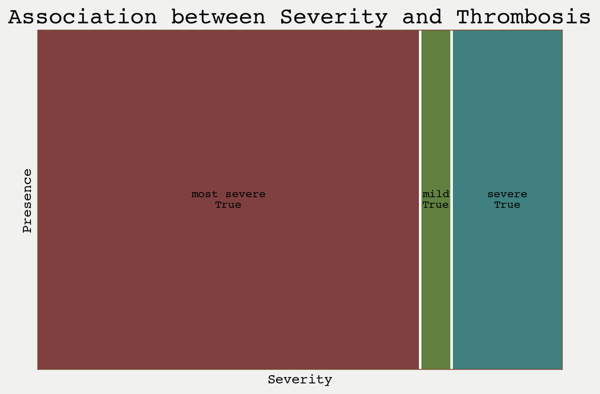

```python
plt.figure(figsize=(10, 6))
mosaic(diag_exam, ['severity', 'thrombosis'], axes_label=False)
plt.xticks(rotation=90, ha='right')
plt.title("Association between Severity and Thrombosis")
plt.ylabel("Presence")
plt.xlabel("Severity")
plt.show()
```

Additonally, whilst trying to understand the association between severity and presence of thrombosis, it would also be better to explore the diagnosis, during the date of examination, and if thrombosis is present, how is the severity? It is seen that ‘Antiphospholipid Syndrome’, ‘Systemic Lupuss Erythematosus’ and ‘Others’ are the diseases which are additionally diagnosed with the presence of severe thrombosis.

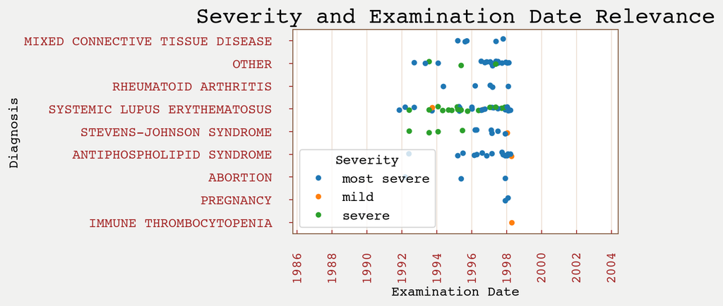

‘Antiphospholipid Syndrome’, ‘Systemic Lupuss Erythematosus’ and ‘Others’ are the diseases which are additionally diagnosed with the presence of severe thrombosis. (Source: Chiba University Database, n.d)

```python
diag_exam=diag_exam.dropna(subset=['diagnosis', 'examination_date', 'severity'])
plt.figure(figsize=(8, 4))
sns.stripplot(data=diag_exam, x='examination_date', y="diagnosis", hue="severity")
plt.xticks(rotation=90)
plt.title("Severity and Examination Date Relevance")
plt.xlabel("Examination Date")
plt.ylabel("Diagnosis")
plt.legend(title="Severity")
plt.show()
```

Though we see the association between the severity and thrombosis, it may not give accurate information since majority of data for ‘severity’ is missing. However, this serves as a good base to understand with the existing data. This also assists us with the future data collection methods.

Systematic Lupus, Other, Antiphospholipid Syndrome are the common Diagnosis in the presence of Thrombosis (Source: Chiba University Database, n.d)

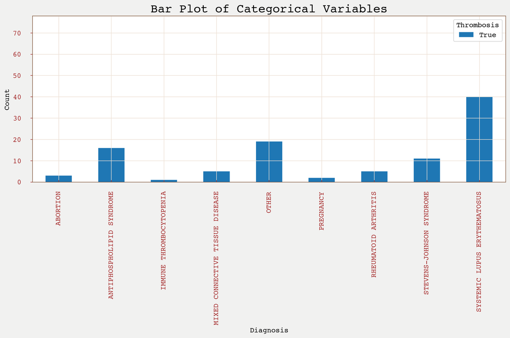

```python
diag_throm = diag_exam.groupby(['diagnosis', 'thrombosis']).size().unstack(fill_value=0)
diag_throm_reset = diag_throm.reset_index()
plt.figure(figsize=(6, 4))
diag_throm_reset.plot(kind='bar', stacked=True, x='diagnosis', figsize=(12, 8))
plt.title('Bar Plot of Categorical Variables')
plt.xlabel('Diagnosis')
plt.ylabel('Count')
plt.legend(title='Thrombosis')
plt.show()
```

```python
col=['a_cl_ig_g', 'a_cl_ig_m', 'a_cl_ig_a']
keep = ['id', 'thrombosis', 'severity']
diag_melted = pd.melt(diag_exam, id_vars=keep, value_vars=col, var_name='Antibody', value_name='Concentration')
print(diag_melted.head(5))
print(diag_melted.shape)
```

```
         id  thrombosis     severity   Antibody  Concentration
0   14872.0        True  most severe  a_cl_ig_g            1.3
1   14872.0        True  most severe  a_cl_ig_g            1.3
2  191207.0        True  most severe  a_cl_ig_g            1.7
3  191207.0        True  most severe  a_cl_ig_g            1.7
4  406320.0        True  most severe  a_cl_ig_g           10.4
(306, 5)
```

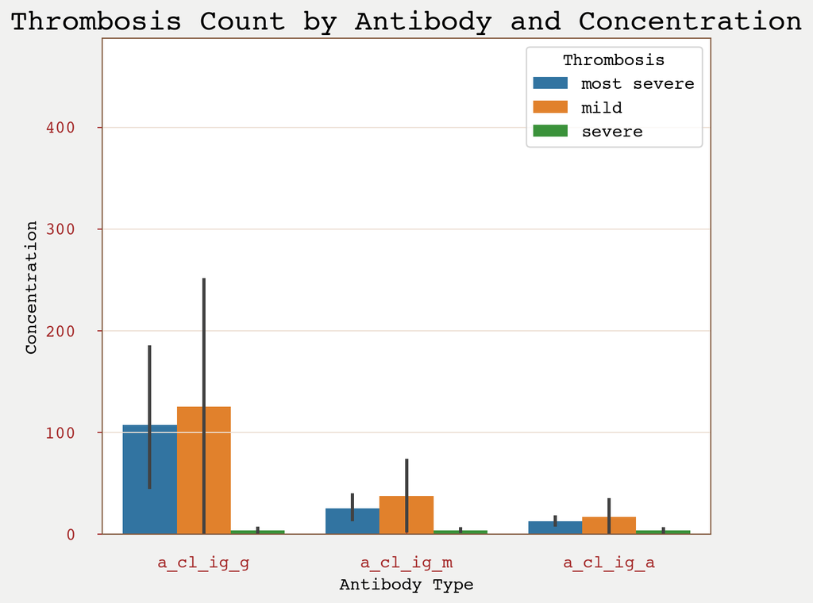

```python
plt.figure(figsize=(7, 6))
sns.barplot(data=diag_melted, x='Antibody', y='Concentration', hue='severity')
plt.title('Thrombosis Count by Antibody and Concentration')
plt.xlabel('Antibody Type')
plt.ylabel('Concentration')
plt.legend(title='Thrombosis')
plt.show()
```

### Question 2

Another interesting aspect I wanted to explore was in terms of the gender data as the risk of thrombosis can vary depending on gender. Do woman’s hormonal fluctuations, pregnancy, and the use of estrogen-based contraceptives play a role?. But males are also susceptible, particularly as they get older. So I’d like to know that though medical history and individual risk factors are important drivers of thrombosis risk, however does gender can also play a role?

For the intial distribution, in terms of the admissions, we see more admissions for Females than Males by a significant percentage. This may indicate a bias towards one gender. Even in terms of admission, more of Females had been admitted than Males. So does gender really play a role?

```
id                             0
examination_date               3
ana_pattern                    0
sex                            1
dob                            0
patient_data_recorded_date    75
hospital_visit_date           65
admission                     12
dtype: int64
            id examination_date ana_pattern sex        dob  \
0      14872.0       1997-05-27           P   F 1953-09-21
1      48473.0       1992-12-21           P   F 1948-10-07
2      48473.0       1992-12-21           S   F 1948-10-07
3     108788.0       1997-05-06           S   F 1942-03-15
4     122405.0       1998-04-02           P   F 1961-05-22
..         ...              ...         ...  ..        ...
403  5765863.0       1998-02-27           S   F 1947-10-19
404  5766000.0       1998-02-27           P   F 1950-01-23
405  5766680.0       1998-03-23           P   F 1969-05-11
406  5771963.0       1998-03-13           P   F 1934-09-30
407  5779550.0       1998-03-31           S   F 1978-10-01

    patient_data_recorded_date hospital_visit_date admission
0                   1997-08-13                 NaT      True
1                   1997-08-13                 NaT      True
2                   1997-08-13                 NaT      True
3                          NaT                 NaT      True
4                          NaT                 NaT     False
..                         ...                 ...       ...
403                 1998-03-24          1998-02-27     False
404                 1998-03-24          1998-02-27      True
405                 1998-07-28          1998-03-02     False
406                 1998-03-24          1998-03-13     False
407                 1998-06-24          1998-03-31     False

[392 rows x 8 columns]
```

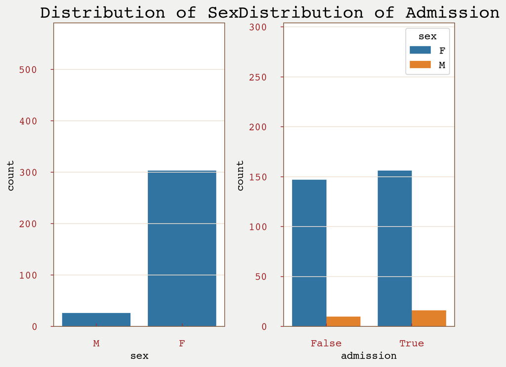

For the intial distribution, in terms of the admissions, we see more admissions for Females than Males by a significant percentage. (Source: Chiba University Database, n.d)

```python
ana_patient = pd.merge(ana, patient, on=['id'], how='inner')
print(ana_patient.isnull().sum()) # shape is 408, 8
print(ana_patient.dropna(subset=['examination_date', 'sex','admission']))
ana_patient= ana_patient.dropna(subset=['examination_date', 'sex','admission', 'hospital_visit_date'])

plt.figure(figsize=(7.5, 6))
plt.subplot(1, 2, 1)
sns.countplot(data=ana_patient, x='sex')
plt.title('Distribution of Sex')

plt.subplot(1, 2, 2)
sns.countplot(data=ana_patient, x='admission', hue="sex")
plt.title('Distribution of Admission')

plt.tight_layout()
plt.show()
```

Though more Females than Males have been admitted in the hospital, what are their individual symptoms they had reported? This is important to know if it is a gender based symptom or a general symptom. Hence, the data has been merged on patient and symptoms, that talks about the patient’s data and the symptoms that patients had during the test. The data has then been manipulated to explore the most common symtpoms in men and women that were specific to them.

We can see that Abortion, Convulsion, Thrombophlebitis, etc are female specific, whereas Budd-Chiari though the incidence is common is Males and Females, it is more common in men in this dataset, followed by Myocardial Infarction. Though these two are most common symptoms for men, for women, all of them listed below were common.

```python
patient_symp=pd.merge(patient, symptoms, on=['id'], how='inner')
patient_symp.isnull().sum() # 74, 8
patient_symp.head(5)

# group by gender
gender_count = patient_symp.groupby(['sex', 'symptom']).size().unstack(fill_value=0)
print(gender_count)
total_count = gender_count.sum()
gender_prop_sym = gender_count.div(total_count)
gender_prop_sym
male_symptoms = gender_prop_sym.loc['M'].sort_values(ascending=False).head(5)
female_symptoms = gender_prop_sym.loc['F'].sort_values(ascending=False).head(5)
```

```
symptom  ABORTION  ACUTE MYOCARDIAL INFARCTION  ANTIPHOSPHOLIPID SYNDROME  \
sex
F               5                            3                          1
M               0                            1                          0

symptom  APOLIPOPROTEIN PRESENT  BRAIN INFARCTION  BUDD-CHIARI  \
sex
F                             1                 6            0
M                             0                 0            1

symptom  CENTRAL NERVOUS SYSTEM LUPUS  CEREBROVASCULAR ACCIDENT  CONVULSION  \
sex
F                                  17                         2           1
M                                   1                         0           0

symptom  EPILEPSY  MYOCARDIAL INFARCTION  OTHER  PULMONARY EMBOLI  \
sex
F               3                      0      6                 1
M               0                      1      0                 0

symptom  PULMONARY HYPERTENSION  SKIN ULCER  THROMBOCYTOPENIA  \
sex
F                             4           3                 5
M                             0           0                 0

symptom  THROMBOPHLEBITIS  THROMBOSIS
sex
F                       4           7
M                       0           0
```

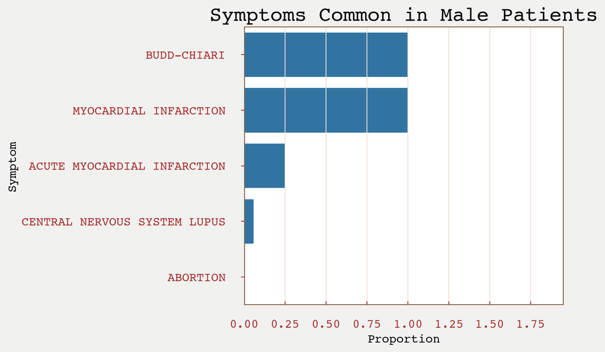

We can see that Abortion, Convulsion, Thrombophlebitis, etc are female specific, whereas Budd-Chiari though the incidence is common is Males and Females, it is more common in men in this dataset, followed by Myocardial Infarction. Though these two are most common symptoms for men, for women, all of them listed below were common. (Source: Chiba University Database, n.d)

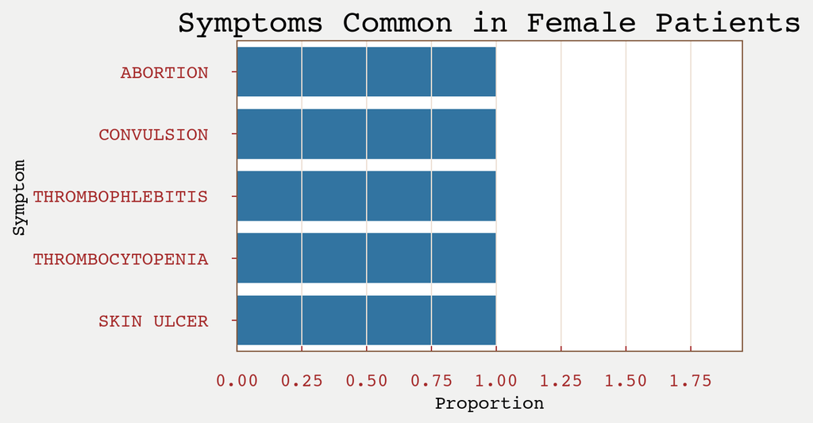

```python
plt.figure(figsize=(8, 5))
sns.barplot(x=male_symptoms.values, y=male_symptoms.index)
plt.title('Symptoms Common in Male Patients')
plt.xlabel('Proportion')
plt.ylabel('Symptom')

plt.figure(figsize=(7, 4))
sns.barplot(x=female_symptoms.values, y=female_symptoms.index)
plt.title('Symptoms Common in Female Patients')
plt.xlabel('Proportion')
plt.ylabel('Symptom')
plt.tight_layout()
plt.show()
```

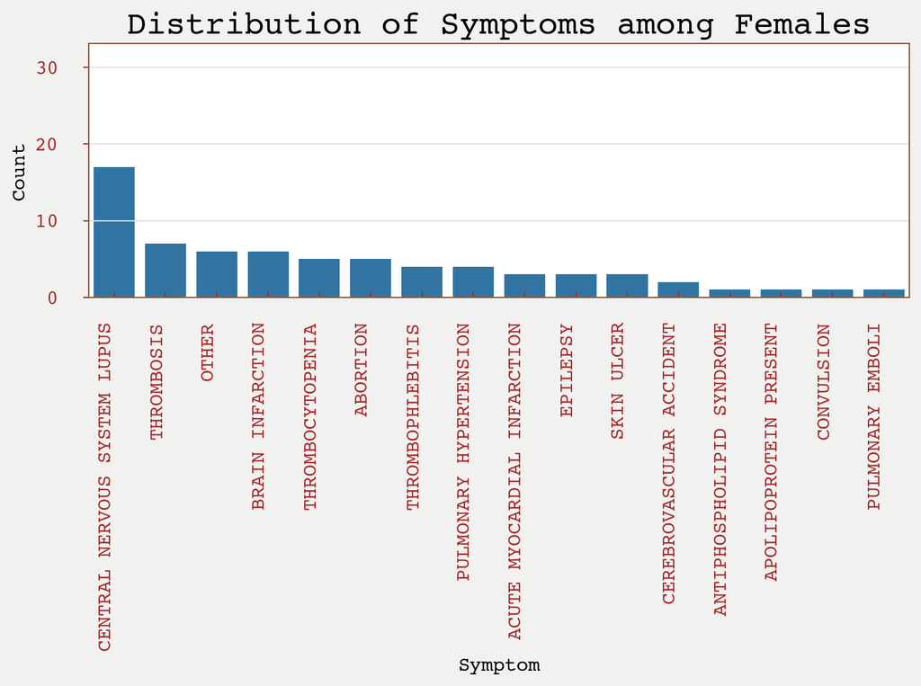

```python
female = patient_symp[patient_symp['sex'] == 'F']
female_count = female['symptom'].value_counts()
plt.figure(figsize=(8, 6))
sns.barplot(x=female_count.index, y=female_count.values)
plt.title('Distribution of Symptoms among Females')
plt.xlabel('Symptom')
plt.ylabel('Count')
plt.xticks(rotation=90, ha='right')
plt.tight_layout()
plt.show()
```

Additionally, to understand the diagnosis of the test taken, the diagnosis and patient data had been merged, with the missing values dropped for ‘date of birth’, ‘sex’, ‘admission’ and ‘hospital_visit_date’ as these are the indicators for further gender exploration.

```python
diag_pat=pd.merge(diagnosis, patient, on=['id'], how='inner')
print(diag_pat.isnull().sum()) # 2020, 8
print(diag_pat.dropna(subset=['dob', 'sex','admission', 'hospital_visit_date']))

female_symp = diag_pat[diag_pat['sex'] == 'F']
print(female_symp.head(2))
symp_count = female_symp['diagnosis'].value_counts()
print(symp_count.head(2))
top_f_symp = symp_count.head(2)
```

```
id                               0
examination_date              1515
diagnosis                        0
sex                             15
dob                              1
patient_data_recorded_date     351
hospital_visit_date            392
admission                       50
dtype: int64
             id examination_date                     diagnosis sex        dob  \
11     133382.0       1996-10-17  SYSTEMIC LUPUS ERYTHEMATOSUS   M 1934-09-03
12     133382.0              NaT  SYSTEMIC LUPUS ERYTHEMATOSUS   M 1934-09-03
13     174116.0       1995-11-13  SYSTEMIC LUPUS ERYTHEMATOSUS   F 1973-02-01
14     174116.0       1995-11-13                         OTHER   F 1973-02-01
15     174116.0              NaT  SYSTEMIC LUPUS ERYTHEMATOSUS   F 1973-02-01
...         ...              ...                           ...  ..        ...
2015  2931207.0              NaT  SYSTEMIC LUPUS ERYTHEMATOSUS   F 1959-01-05
2016  2931207.0              NaT     ANTIPHOSPHOLIPID SYNDROME   F 1959-01-05
2017  3385021.0              NaT  SYSTEMIC LUPUS ERYTHEMATOSUS   F 1987-12-05
2018  4826981.0              NaT  SYSTEMIC LUPUS ERYTHEMATOSUS   F 1963-07-21
2019  5075166.0              NaT       PAGET-SCHOTTER SYNDROME   F 1957-10-30

     patient_data_recorded_date hospital_visit_date admission
11                   1996-12-05          1992-10-13      True
12                   1996-12-05          1992-10-13      True
13                   1991-08-13          1976-12-09      True
14                   1991-08-13          1976-12-09      True
15                   1991-08-13          1976-12-09      True
...                         ...                 ...       ...
2015                 1994-02-08          1993-11-01     False
2016                 1994-02-08          1993-11-01     False
2017                 1994-02-19          1985-05-14      True
2018                 1994-03-08          1992-07-14     False
2019                 1994-02-08          1993-11-26      True

[1586 rows x 8 columns]
        id examination_date                        diagnosis sex        dob  \
0  14872.0       1997-05-27  MIXED CONNECTIVE TISSUE DISEASE   F 1953-09-21
1  14872.0       1997-05-27                            OTHER   F 1953-09-21

  patient_data_recorded_date hospital_visit_date admission
0                 1997-08-13                 NaT      True
1                 1997-08-13                 NaT      True
STEVENS-JOHNSON SYNDROME        447
SYSTEMIC LUPUS ERYTHEMATOSUS    426
Name: diagnosis, dtype: int64
```

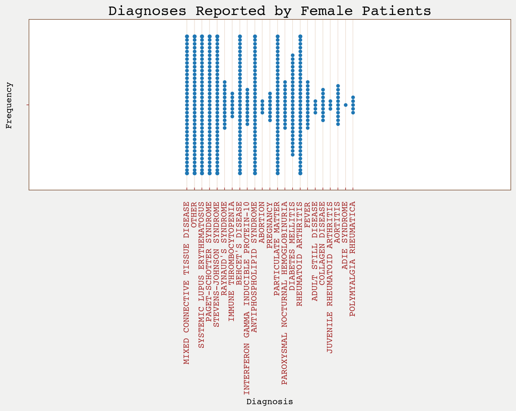

```python
plt.figure(figsize=(10, 8))
sns.swarmplot(data=female_symp, x='diagnosis')
plt.title('Diagnoses Reported by Female Patients')
plt.xlabel('Diagnosis')
plt.ylabel('Frequency')
plt.xlim()
plt.xticks(rotation=90)
plt.show()
```

## Question 3

For me, another interesting aspect to explore is the diagnosis and the presence of thrombosis. Firstly, to understand the relationship between Examination date and Thrombosis, we see there is no relationship between the Examination Date and Thrombosis, showcasing no signs of temporal trends. This specific graph doesn’t really give us any more information, hence we need to explore further.

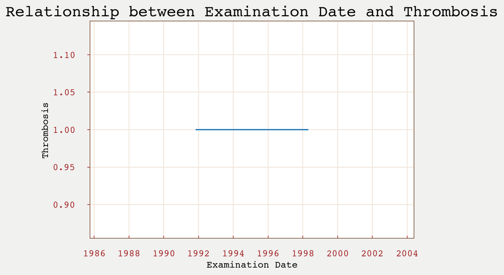

We see there is no relationship between the Examination Date and Thrombosis, showcasing no signs of temporal trends. (Source: Chiba University Database, n.d)

```python
diag_exam['thrombosis'] = diag_exam['thrombosis'].fillna(0)
plt.figure(figsize=(7, 5))
sns.lineplot(data=diag_exam, x='examination_date', y='thrombosis')
plt.title('Relationship between Examination Date and Thrombosis')
plt.xlabel('Examination Date')
plt.ylabel('Thrombosis')
plt.show()
```

For exploring thrombosis, we need to understand the general admission status and using a pie chart, we see that around 60% of the people have not been admitted. But pie chart is not a reliable method as though it showcases percentages, it doesn’t show the exact quantities.

We see that around 60% of the people have not been admitted. (Source: Chiba University Database, n.d)

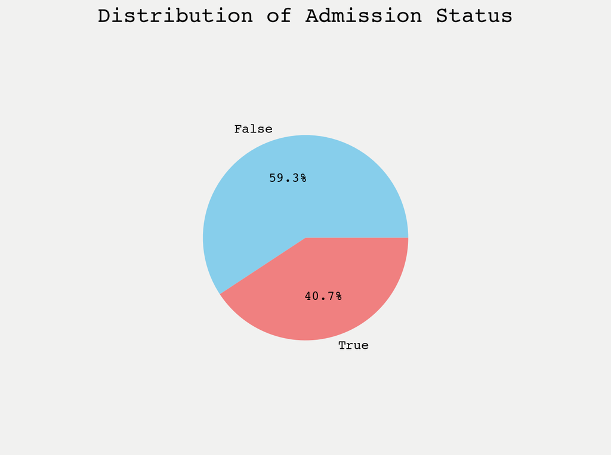

```python
plt.figure(figsize=(8, 6))
admission_counts = patient['admission'].value_counts()
plt.figure(figsize=(8, 6))
plt.pie(admission_counts, labels=admission_counts.index, autopct='%1.1f%%', colors=['skyblue', 'lightcoral'])
plt.title('Distribution of Admission Status')
plt.axis('equal')
plt.show()
```

However, more than pie chart, a count plot showcases the counts of the dataset. This is a reliable metho and tells me that only around 500 people have been admitted in the hospital.

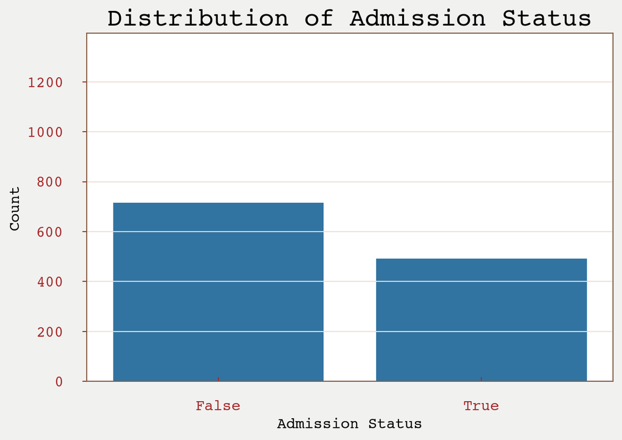

We see that majority of the people have not been admitted. (Source: Chiba University Database, n.d)

```python
sns.countplot(data=patient, x='admission')
plt.title('Distribution of Admission Status')
plt.xlabel('Admission Status')
plt.ylabel('Count')
plt.show()
```

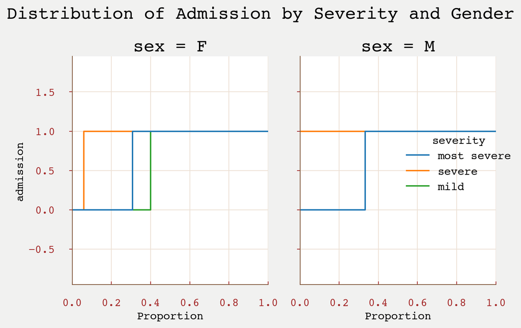

```python
exam_pat=pd.merge(exam, patient,  on=['id'], how='inner')
exam_pat.isnull().sum() # 417, 16

plt.figure(figsize=(5, 6))
sns.displot(
    data=exam_pat, y="admission", hue="severity", col="sex",
    kind="ecdf", height=5, aspect=.6,
)
plt.ylabel("Admission")
plt.suptitle("Distribution of Admission by Severity and Gender", fontsize=19)
plt.subplots_adjust(top=0.88)
plt.show()
```

In understand the final aspect of this dataset, is the number of hospital visits per recorded date and we see that the incidence of hospital visits were higher between 1997 and 1998. This showcases an interesting pattern about whether there was any specific cause for this?

```
   patient_data_recorded_date  count
0                  1991-06-10      1
1                  1991-08-12     15
2                  1991-08-13     26
3                  1992-01-20      0
4                  1992-02-28      2
..                        ...    ...
92                 1998-08-31      1
93                 1998-09-01      2
94                 1998-09-02      1
95                 1998-09-14      0
96                 1998-12-03      1

[97 rows x 2 columns]
patient_data_recorded_date    datetime64[ns]
count                                  int64
dtype: object
```

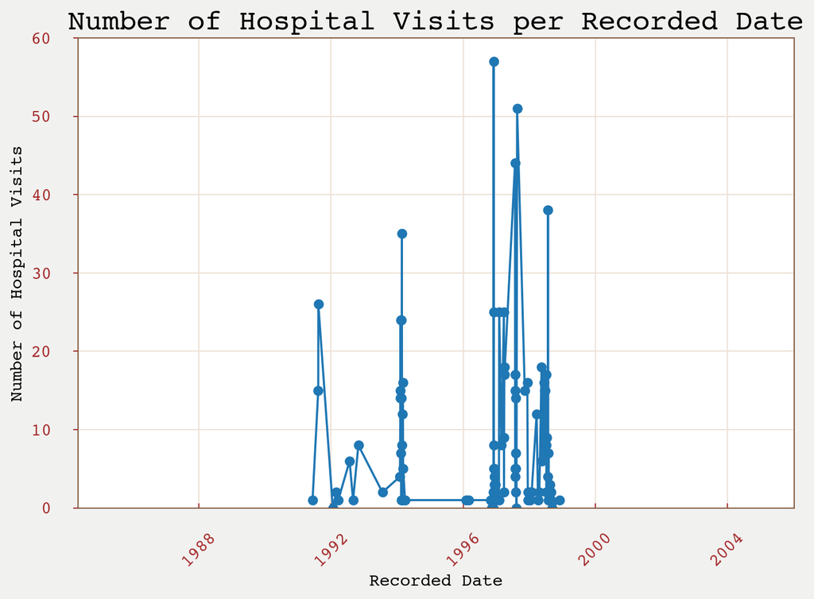

We see that the incidence of hospital visits were higher between 1997 and 1998. (Source: Chiba University Database, n.d)

```python
admission_vs_visit_count = patient.groupby('patient_data_recorded_date')['hospital_visit_date'].count()

admission_vs_visit_count_df = admission_vs_visit_count.reset_index(name='count')

print(admission_vs_visit_count_df)
print(admission_vs_visit_count_df.dtypes)

plt.figure(figsize=(8, 6))
plt.plot(admission_vs_visit_count_df['patient_data_recorded_date'], admission_vs_visit_count_df['count'], marker='o', linestyle='-')
plt.title('Number of Hospital Visits per Recorded Date')
plt.xlabel('Recorded Date')
plt.ylabel('Number of Hospital Visits')
plt.xticks(rotation=45)
plt.ylim(0, 60)
plt.grid(True)
plt.tight_layout()
plt.show()
```

Additionally, since we have explored the other variables that give us information about thrombosis, like admission status, examination date, hospital visitation dates, a contingency table has been created for the diagnosis and thrombosis to assess the dependancy. As the p value is 1, this means there is no dependancy between Diagnosis and Thrombosis, however, we can see that those with Thrombosis have also been diagnosed with Lupus.

```
 The chi-squared value is: 0.0
The p-value is: 1.0
```

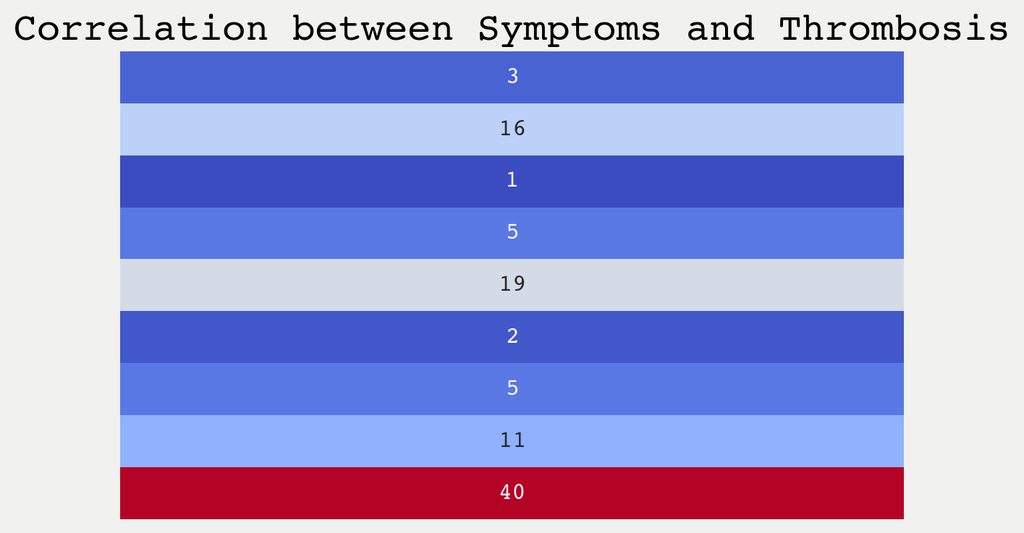

```python
#  label: Correlation between Symptoms and Thrombosis
#| fig-cap: "As the p value is 1, this means there is no dependancy between Diagnosis and Thrombosis, however, we can see that those with Thrombosis have also been diagnosed with Lupus. (Source: Chiba University Database, n.d)"

contingency = pd.crosstab(diag_exam['diagnosis'], diag_exam['thrombosis'])

chi2, p, _, _ = chi2_contingency(contingency)

print(" The chi-squared value is:", chi2)
print("The p-value is:", p)

plt.figure(figsize=(6, 4))
sns.heatmap(contingency, annot=True, fmt='d', cmap='coolwarm', cbar=False)
plt.title('Correlation between Symptoms and Thrombosis')
plt.xlabel('Thrombosis')
plt.ylabel('Symptoms')
plt.axis("off")
plt.show()
```

### Question 4

The final question I wanted to explore was in terms of age, and see how age plays a role in detecting thrombosis.

For the age to be calculated, the date of birth of the patient and the hospital visit date was used. Looking at the graph, we see that 0 refers to ‘No admission’ and 1 refers to ‘Admission’, so we see that for patients between 18-29 have veeb admitted the most, and those aged 70 and above have been admitted the least. This provides a base to understand if age does play a role for thrombosis.

```
            dob hospital_visit_date   age
0    1934-02-13          1993-02-10  59.0
1    1937-05-02          1973-01-01  35.0
2    1956-04-14                 NaT   NaN
3    1953-09-21                 NaT   NaN
4    1936-03-25          1992-02-03  55.0
...         ...                 ...   ...
1235 1987-12-05          1985-05-14  -3.0
1236 1947-06-06          1989-09-29  42.0
1237 1963-07-21          1992-07-14  29.0
1238 1957-10-30          1993-11-26  36.0
1239 1950-09-04          1996-05-31  45.0

[1240 rows x 3 columns]
```

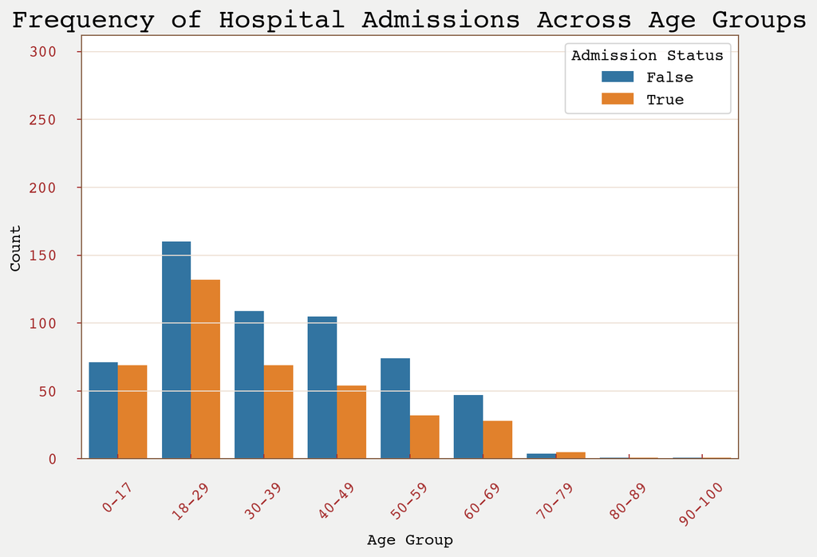

```python
patient['age'] = (patient['hospital_visit_date'] - patient['dob']).dt.days // 365

print(patient[['dob', 'hospital_visit_date', 'age']])

age_groups = pd.cut(patient['age'], bins=[0, 18, 30, 40, 50, 60, 70, 80, 90, 100],
                    labels=['0-17', '18-29', '30-39', '40-49', '50-59', '60-69', '70-79', '80-89', '90-100'])

plt.figure(figsize=(8, 6))
sns.countplot(data=patient, x=age_groups, hue='admission')
plt.title('Frequency of Hospital Admissions Across Age Groups')
plt.xlabel('Age Group')
plt.ylabel('Count')
plt.xticks(rotation=45)
plt.legend(title='Admission Status')
plt.show()
```

Hence, in terms of age, the final question to be answered is the presence of correlation between age group and the frequency of diagnosis. We see that those aged 18-29 have the most common symtoms of Stevens-Johnson Syndrome and Systemic Lupus Erythematosus

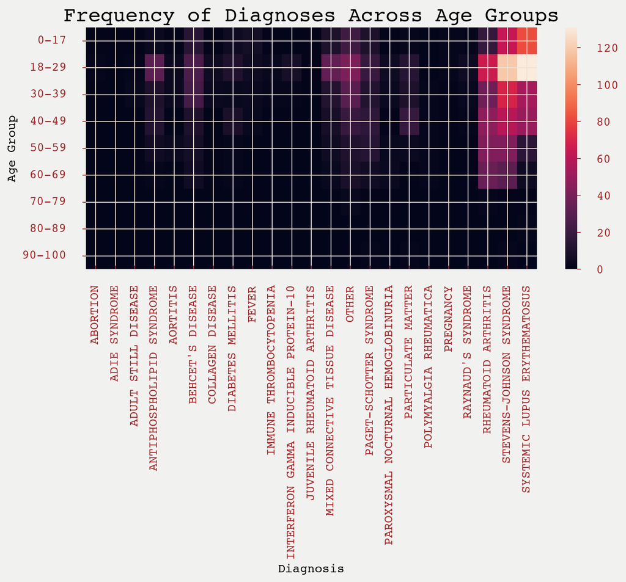

```python
diag_pat['age'] = (diag_pat['hospital_visit_date'] - diag_pat['dob']).dt.days // 365

#print(diag_pat[['dob', 'hospital_visit_date', 'age']])

age_groups1 = pd.cut(diag_pat['age'], bins=[0, 18, 30, 40, 50, 60, 70, 80, 90, 100],
                    labels=['0-17', '18-29', '30-39', '40-49', '50-59', '60-69', '70-79', '80-89', '90-100'])
diagnosis_counts = diag_pat.groupby([age_groups1, 'diagnosis']).size().unstack(fill_value=0)

plt.figure(figsize=(9, 8))
sns.heatmap(diagnosis_counts, annot=False, fmt='d')
plt.title('Frequency of Diagnoses Across Age Groups')
plt.xlabel('Diagnosis')
plt.ylabel('Age Group')
plt.xticks(rotation=90)
plt.yticks(rotation=0)
plt.show()
```

# Conclusions

This has been an interesting dataset to work with. After initial data exploration and cleaning, I have realised the importance of “no size fits all” approach. Though we are taught tidying the dataset meant removing all the columns and imputing the values, this data project tries to show us the reality of dataset. Most of the data in real life is messy and we need to make sense of it.